# Trabajo Práctico

Laboratorio de Datos

Antonio, Cristian

Hsueh, Noe

Manusovich, Pablo

**Sobre esta versión.** La primera parte conserva el análisis de 2021 y los resultados del informe original. La segunda incorpora la revisión corregida de 2015 y 2019, con la evolución anual de 2015 a 2020.

**Objetivo**: Hacer un análisis descriptivo / exploratorio con un conjunto de datos.

**Dataset**: Aterrizajes y despegues registrados por la Empresa Argentina de Navegación Aérea (EANA). Ministerio de transporte. Detalle de aterrizajes y despegues registrados por la Empresa Argentina de Navegación Aérea. Desde enero-2014 hasta diciembre-2020.

*Carga de paquetes*

```r
require(tidyverse)
require(dplyr)
require(lubridate)
require(readr)
require(rvest)
require(xml2)
require(geosphere)
require(ggmosaic)
require(gridExtra)

# mapas
require(ggrepel)
require(ggplot2)
require(tmap)
require(sf)

# grafos
require(igraph)
require(ggraph)
require(tidygraph)
require(networkD3)
```

# 1 Primera parte

**Consigna**

- Hagan una limpieza de los datos, revisando cada una de las variables a fin de ver que no contengan errores o casos extraños.
- Quedarse con vuelos nacionales.
- El dataset tiene el código de los aeropuertos. Agreguen nuevas variables con la ciudad, provincia y coordenadas que corresponde a cada aeropuerto. Pueden encontrar esta información en este artículo de [Wikipedia](https://en.wikipedia.org/wiki/List_of_airports_in_Argentina). *Observación:* se optó por usar la base de datos `datos_sna`, provista por la cátedra, dado que la base de wikipedia estaba incompleta.
- Calculen la distancia recorrida por cada vuelo. La función`distHaversine` del paquete `geosphere` puede resultarles útil.
- Calculen la velocidad media de cada vuelo. Para esto deberán asociar distintas filas del dataset. El dataset contiene Despegues y Aterrizajes, que permiten encontrar la hora de partida y llegada de cada vuelo.

Cargamos `datos_sna` que contiene información georeferencial sobre los aeropuertos que se utilizarán para la primera parte del TP. Luego cargamos los datos de los vuelos del 2021.

Realicemos una exploración básica del dataset que se nos presentó. Esto nos ayudará a limpiar la base de datos y facilitar el análisis posterior. Empecemos analizando la variable *Clasificación de vuelo*, esta nos indica si un vuelo es doméstico o si es internacional. Debido a la pandemia, es esperable que observemos muchos más vuelos domésticos que internacionales. A continuación presentamos una tabla con la proporciones de vuelos nacionales e internacionales.

```r
t <- prop.table(table(datos_2021$`Clasificación Vuelo`))
df_cv <- as.data.frame(t)
round(t,3)
```

```
##
##   Dom Inter
## 0.898 0.102
```

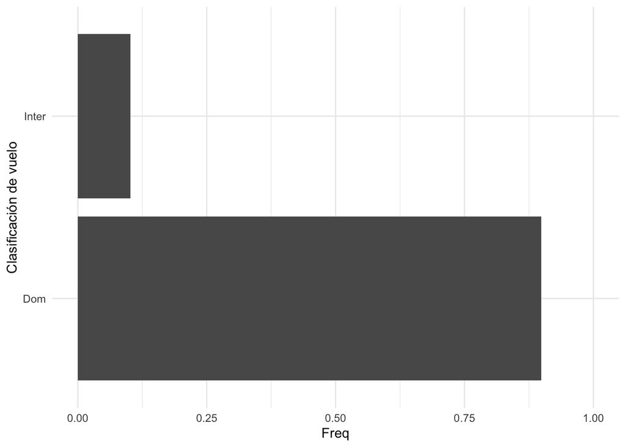

Figure 1.1: Proporción de clases de vuelos durante el 2021

```r
ggplot(df_cv, aes(x=Var1, y=Freq)) +
  coord_flip() +
  geom_col() +
  xlab("Clasificación de vuelo") +
  ylim(0,1) +
  theme_minimal()
```

A partir de la Figura 1.1, notamos que son muy pocos los vuelos internacionales, tal como habíamos supuesto.

De los vuelos domésticos, veamos ahora cuáles son los aeropuertos con más vuelos (aterrizajes y despegue):

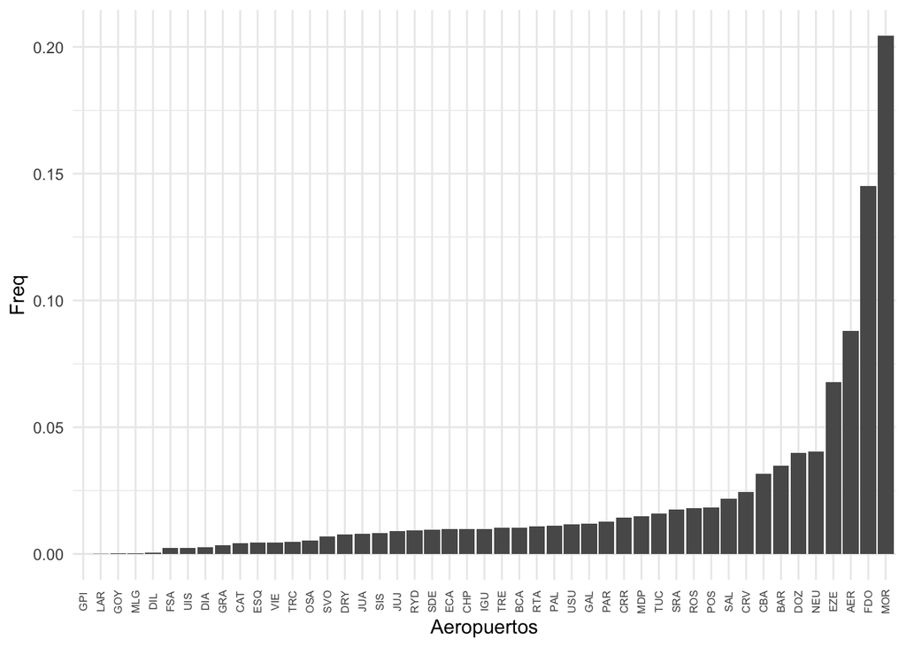

Figure 1.2: Frquencia de vuelos por aeropuertos domésticos

```r
df_dom <- datos_2021 %>% filter(`Clasificación Vuelo`=="Dom")
t <- prop.table(table(df_dom$Aeropuerto))
df_aer <- as.data.frame(t)
ggplot(df_aer, aes(x=reorder(Var1, Freq), y=Freq)) +
  geom_col() +
  theme_minimal() +
  xlab("Aeropuertos") +
  theme(axis.text.x = element_text(size=6, angle = 90, vjust = 0.5))
```

Al observar la figura 1.2, notamos que los tres aeropuertos con más vuelos son los de Morón (MOR), San Fernando (FDO) y el aeroparque (AER). Sin embargo, cabe destacar que la mayorías de los vuelos que salen o entran a los aeropuertos de Morón y San Fernando pertenecen a vuelos no regulares, es decir, aquellos que están etiquetados como no regular, vuelos privados, vuelos escuela, entre otros. Para nuestro análisis de velocidad media vamos a considerar solamente los vuelos regulares, razón por la cual estos datos serán descartado para el análisis.

```r
datos_2021 %>%
  filter(Aeropuerto=="MOR"| `Origen / Destino`=="MOR" | Aeropuerto=="FDO" | `Origen / Destino`=="FDO") %>%
  group_by(`Clase de Vuelo (todos los vuelos)`) %>%
  count(sort=T)
```

| Clase de Vuelo (todos los vuelos) | n |
| --- | --- |
| Vuelo Escuela | 29321 |
| Vuelo Privado con Matrícula Nacional | 24163 |
| No Regular | 8166 |
| Vuelo Oficial Nacional | 2049 |
| Vuelo Privado con Matrícula Extranjera | 825 |
| Vuelo Oficial Extranjero | 73 |
| Trabajo Aéreo | 16 |
| Regular | 11 |

Luego procedimos a una primera limpieza de la base de datos. Nos quedaremos con los vuelos domésticos, de tipo regular y aquellas que tengan un nombre de aerolínea. Por otra parte, agregamos una columna que corresponde a la distancia recorrida `dist_rec_km` en km.

```r
datos_2021 <- datos_2021 %>%
  filter(`Clasificación Vuelo`=="Dom",
         `Clase de Vuelo (todos los vuelos)`=="Regular",
         `Aerolinea Nombre`!= 0) %>%
  select(-c(`Clasificación Vuelo`)) %>%
  rename(Salida_ANA = Aeropuerto,
         Llegada_ANA = `Origen / Destino`)

datos_2021 <- left_join(datos_2021, datos_sna[-6], by="Salida_ANA") %>%
  rename(Ciudad.Origen = nom_ciudad, Provincia.Origen = cpr, lat_origen = x, lon_origen = y)

datos_2021 <- left_join(datos_2021, datos_sna[-3], by="Llegada_ANA") %>%
  rename(Ciudad.Destino = nom_ciudad, Provincia.Destino = cpr, lat_destino=x, lon_destino=y)

datos_2021 <- datos_2021 %>%
  mutate(dist_rec_km = round(distHaversine(p1=cbind(lon_origen, lat_origen),
                                           p2=cbind(lon_destino, lat_destino))/1000))
```

Dividimos la base de datos original en dos, una de despegue y otra de aterrizaje, esto nos permitirá hacer un matcheo de la gran parte de los vuelos y así obtener el tiempo de vuelo.

En la tabla `info_vuelos`, calculamos para los vuelos matcheados la distancia recorrida, le mediana del tiempo de vuelo y la velocidad media del vuelo. En el ejemplo que vemos abajo, vemos que de EZE (Ezeiza) a BAR (Bariloche), la distancia recorrida es de 1434 km, la mediana del tiempo de vuelo es de casi 2 horas (1.88) y con esto estimamos que la velocidad media de vuelo es aproximadamente de 761 km/h.

| Salida_ANA | Llegada_ANA | dist | mediana_tiempoDeVuelo | n | velocidad_de_vuelo_kmH |
| --- | --- | --- | --- | --- | --- |
| EZE | BAR | 1434 | 1.883333 | 732 | 761.4159 |
| BAR | AER | 1451 | 1.750000 | 715 | 829.1429 |
| AER | BAR | 1451 | 2.000000 | 699 | 725.5000 |
| BAR | EZE | 1434 | 1.733333 | 612 | 827.3077 |
| AER | CBA | 668 | 1.083333 | 602 | 616.6154 |
| CBA | AER | 668 | 0.950000 | 600 | 703.1579 |

Para poder entender mejor los resultados que obtuvimos, realizamos un resumen estadístico y un boxplot:

```r
summary(info_vuelos$velocidad_de_vuelo_kmH)
```

```
##    Min. 1st Qu.  Median    Mean 3rd Qu.    Max.
##   105.0   344.2   481.1   484.5   621.2   891.5
```

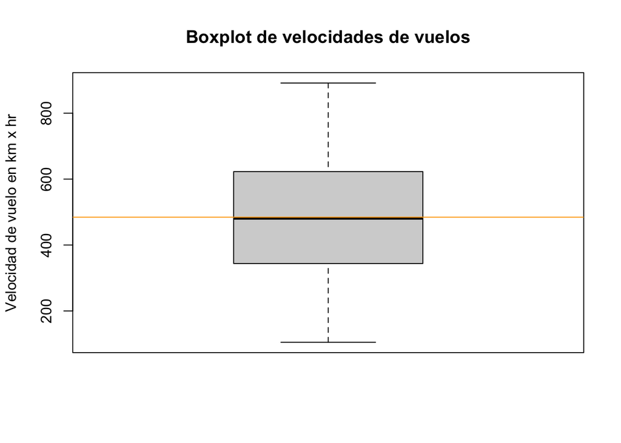

Figure 1.3: Boxplot velocidad de vuelo en km x hr

```r
boxplot(info_vuelos$velocidad_de_vuelo_kmH, ylab="Velocidad de vuelo en km x hr", main="Boxplot de velocidades de vuelos")
abline(h = mean(info_vuelos$velocidad_de_vuelo_kmH), col='orange')
```

A partir de la figura 1.3, vemos que la mediana de las velocidades es de 481 km/h y la mayor parte de los vuelos vuelan con una velocidad de entre 344 km/h y 621 km/h.

# 2 Segunda parte — comparación de 2015 y 2019

**Consigna**

- Usando las herramientas que aprendieron, exploren los datos. Piensen preguntas que les despierten interés y generen hipótesis que den posibles respuestas, en base a las magnitudes y visualizaciones que vimos en clase.
- Reporten las preguntas que se hicieron y las hipótesis que generaron, buscando construir una narrativa. Es necesario mezclar texto, código y visualizaciones.

*Sugerencia para la Parte 2:* Tomen cada variable y piensen qué información les brinda, cómo la representarían y resumirían. Luego, tomen cada par de variables posibles y piensen qué relación se obtiene de ellas. Tomen las que les resulten más interesantes, resumanlas y representenlas.

```r
paquetes <- c("dplyr", "tidyr", "stringr", "ggplot2", "maps", "gridExtra",
              "igraph", "ggraph", "tidygraph", "networkD3", "knitr", "rmarkdown")
faltantes <- paquetes[!vapply(paquetes, requireNamespace, logical(1), quietly=TRUE)]
if (length(faltantes)) {
  comando <- paste0("install.packages(c(",
                    paste(sprintf('\"%s\"', faltantes), collapse=", "), "))")
  stop("Faltan paquetes. Ejecutá en la consola: ", comando, call.=FALSE)
}
invisible(lapply(paquetes, function(p) {
  suppressPackageStartupMessages(library(p, character.only=TRUE))
}))
knitr::opts_chunk$set(warning=FALSE, message=FALSE)

# Knit usa el directorio del Rmd. Al ejecutar desde el editor de RStudio,
# buscamos también el documento activo; fuera de RStudio se usa getwd().
entrada <- tryCatch(knitr::current_input(dir=TRUE), error=function(e) "")
if (!length(entrada)) entrada <- ""
if (!nzchar(entrada) && interactive() &&
    requireNamespace("rstudioapi", quietly=TRUE) && rstudioapi::isAvailable()) {
  entrada <- rstudioapi::getSourceEditorContext()$path
}
raiz_tp <- if (nzchar(entrada) && file.exists(entrada)) {
  dirname(normalizePath(entrada, winslash="/", mustWork=TRUE))
} else {
  normalizePath(getwd(), winslash="/", mustWork=TRUE)
}
dir_datos <- file.path(raiz_tp, "dataset")
dir.create(dir_datos, recursive=TRUE, showWarnings=FALSE)
message("Carpeta de datos: ", dir_datos)
```

```
## Carpeta de datos: C:/Users/crist/Downloads/dataset
```

```r
options(timeout=max(300L, getOption("timeout", 60L)))

url_datos <- "https://raw.githubusercontent.com/marouxet/visualizacion_vuelos_aeropuertos/36b2137b789377a3352d3af48eaa3d705f2f1d5f/"
md5_esperados <- c(
  "2015"="8824366c4a437a4d32051e148ba4313f",
  "2016"="069e5b2378a7d29fbab135c1ed307b95",
  "2017"="c506ad85fa91e4d7958ebd998ba63779",
  "2018"="d790c6317a6acfa2c74439c2688c720e",
  "2019"="3b7752a2facb3da63485106238f5e60d",
  "2020"="7947cb4f4403bc755616db5973fa150c"
)

obtener_csv <- function(anio) {
  nombre <- paste0("aterrizajes-y-despegues-registrados-por-eana-", anio, ".csv")
  archivo <- file.path(dir_datos, nombre)
  if (!file.exists(archivo)) {
    message("Descargando datos de ", anio, "...")
    temporal <- tempfile(pattern=paste0("vuelos_", anio, "_"), tmpdir=dir_datos)
    on.exit(unlink(temporal), add=TRUE)
    estado <- tryCatch(
      utils::download.file(paste0(url_datos, nombre), temporal,
                           mode="wb", method="libcurl", quiet=FALSE),
      error=function(e) stop(
        "No se pudo descargar ", nombre, ". Extraé el ZIP completo junto al Rmd. Detalle: ",
        conditionMessage(e), call.=FALSE)
    )
    if (estado != 0L || !file.exists(temporal)) {
      stop("La descarga no se completó: ", nombre, call.=FALSE)
    }
    if (unname(tools::md5sum(temporal)) != unname(md5_esperados[as.character(anio)])) {
      stop("El archivo descargado está incompleto o difiere de la copia verificada: ",
           nombre, call.=FALSE)
    }
    if (!file.rename(temporal, archivo)) {
      stop("No se pudo guardar el CSV en ", dir_datos, call.=FALSE)
    }
  }
  archivo
}
```

## Introducción

La motivación del presente trabajo parte de la información preexistente por parte de los integrantes de este grupo de que durante el lapso 2015 y 2019 tuvieron lugar cierto fenómenos en el mundo aerocomercial argentino (inauguración de aeropuertos, surgimiento de empresas de vuelos low-cost, diversificación del mercado de vuelos) que estarían reflejando un proceso de cambio que sería razonable poder abordarlo y cuantificarlo haciendo uso de los datos provistos.

Veamos cómo evolucionó la cantidad de despegues regulares no internacionales entre 2015 y 2020. Usamos el mismo criterio de selección para todos los años y conservamos un registro de las filas retenidas.

```r
# No exigimos coordenadas ni tipo de aeronave para contar vuelos.
# Los faltantes geográficos se tratan después, en el análisis que los necesita.
leer_vuelos <- function(anio) {
  archivo <- obtener_csv(anio)
  originales <- read.csv(
    archivo, fileEncoding = "latin1", sep = ";", strip.white = TRUE,
    stringsAsFactors = FALSE
  )
  requeridas <- c("Fecha", "Clase.de.Vuelo", "Clasificación.Vuelo",
                 "Tipo.de.Movimiento", "Origen.OACI", "Destino.OACI",
                 "Aerolinea.Nombre")
  if (!all(requeridas %in% names(originales))) {
    stop("Faltan columnas en ", archivo, ": ",
         paste(setdiff(requeridas, names(originales)), collapse = ", "))
  }
  originales <- originales %>%
    mutate(across(where(is.character), ~ na_if(trimws(.x), "")))
  originales$Fecha <- as.Date(originales$Fecha, format = "%d/%m/%Y")

  despegues <- originales %>%
    filter(Clasificación.Vuelo != "Internacional",
           Clase.de.Vuelo == "Regular",
           Tipo.de.Movimiento == "Despegue")
  datos <- despegues %>%
    filter(!is.na(Aerolinea.Nombre), Aerolinea.Nombre != "N/A") %>%
    mutate(Aerolinea.Nombre = case_when(
      str_detect(Aerolinea.Nombre, "LATAM") ~ "LATAM",
      str_detect(Aerolinea.Nombre, "LADE") ~ "LADE",
      str_detect(Aerolinea.Nombre, "Norwegian") ~ "Norwegian",
      str_detect(Aerolinea.Nombre, "Gol") ~ "Gol",
      str_detect(Aerolinea.Nombre, "Azul") ~ "Azul Linhas Aéreas",
      TRUE ~ Aerolinea.Nombre
    ))
  control <- tibble(
    anio = anio,
    filas_originales = nrow(originales),
    despegues_regulares_no_internacionales = nrow(despegues),
    sin_aerolinea_identificada = nrow(despegues) - nrow(datos),
    vuelos_retenidos = nrow(datos),
    fechas_faltantes_retenidas = sum(is.na(datos$Fecha))
  )
  list(datos = datos, control = control)
}

# Formato para que las cifras del texto se actualicen al ejecutar el informe.
fmt_num <- function(x) {
  formatC(x, format = "f", digits = 0, big.mark = ".", decimal.mark = ",")
}
fmt_pct <- function(x) {
  ifelse(is.na(x), "no calculable", formatC(x, format = "f", digits = 1,
                                            decimal.mark = ","))
}

anios <- 2015:2020
# Conservamos las filas de 2015 y 2019; para los demás años solo
# necesitamos el resumen anual. Así se reduce el uso de memoria.
cargas <- list()
controles <- vector("list", length(anios))
for (i in seq_along(anios)) {
  carga <- leer_vuelos(anios[i])
  controles[[i]] <- carga$control
  if (anios[i] %in% c(2015, 2019)) cargas[[as.character(anios[i])]] <- carga
}
rm(carga)
control_lectura <- bind_rows(controles)
control_lectura
```

| anio | filas_originales | despegues_regulares_no_internacionales | sin_aerolinea_identificada | vuelos_retenidos | fechas_faltantes_retenidas |
| --- | --- | --- | --- | --- | --- |
| 2015 | 292952 | 73720 | 32 | 73688 | 0 |
| 2016 | 291117 | 75431 | 25 | 75406 | 0 |
| 2017 | 323403 | 82858 | 27 | 82831 | 0 |
| 2018 | 339022 | 93138 | 38 | 93100 | 0 |
| 2019 | 398994 | 117524 | 27 | 117497 | 0 |
| 2020 | 136763 | 29779 | 18 | 29761 | 0 |

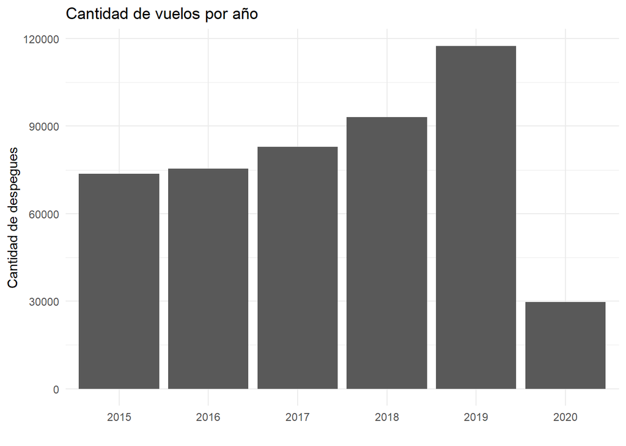

Despegues regulares no internacionales por año

```r
vuelos_por_anio <- control_lectura %>%
  select(anio, n = vuelos_retenidos)

ggplot(vuelos_por_anio, aes(x = as.factor(anio), y = n)) +
  geom_col() +
  ggtitle("Cantidad de vuelos por año") +
  xlab("") + ylab("Cantidad de despegues") + theme_minimal()
```

El gráfico anual permite comparar la evolución anual. El análisis que sigue se centra en 2015 y 2019; 2020 queda como referencia del comienzo de la pandemia.

Nos hemos propuesto a analizar los cambios en los vuelos de los años 2015 y 2019 y estudiar los cambios en el mapa de los vuelos comerciales que tuvieron lugar en nuestro país. Para ello, comenzamos comparando la cantidad de vuelos en dichos años, las empresas más relevantes que lo llevaron a cabo y las regiones geográficas que tuvieron como destino dicho vuelo. Esto nos permitirá verificar si la hipótesis de los cambios que tuvieron lugar en dicho periodo es confirmado con los datasets proporcionados.

Para el estudio, tendremos en cuenta los siguientes puntos:

1. la cantidad de vuelo en el 2015 y 2019
2. el conexiones de los vuelos en el 2015 y 2019
3. las aerolíneas que llevaron a cabo esos vuelos.

Nos enfocarnos en varios niveles de profundidad: en el aspecto nacional, regional o provincial y local.

**Carga de información**

Incorporamos ciudad, provincia y coordenadas a partir de una [revisión histórica de Wikipedia](https://en.wikipedia.org/w/index.php?title=List_of_airports_in_Argentina&oldid=1036984107), del 2021-08-03. La tabla se incluye en este archivo para que no cambie entre ejecuciones. No se asegura que sea la misma revisión exacta utilizada en la entrega original.

```r
texto_aeropuertos <- paste(c(
  "City served,Province,ICAO,Coordinates",
  "Alto Río Senguer,Chubut,SAVR,45°00′48″S 070°48′46″W / 45.01333°S 70.81278°W",
  "Ascochinga,Córdoba,SACN,30°59′25″S 064°14′39″W / 30.99028°S 64.24417°W",
  "Azul,Buenos Aires,SAZA,36°50′14″S 059°52′51″W / 36.83722°S 59.88083°W",
  "Bahía Blanca,Buenos Aires,SAZB,38°43′29″S 062°10′09″W / 38.72472°S 62.16917°W",
  "Bariloche,Río Negro,SAZS,41°09′04″S 071°09′27″W / 41.15111°S 71.15750°W",
  "Benito Juárez,Buenos Aires,SAZJ,37°42′22″S 059°47′31″W / 37.70611°S 59.79194°W",
  "Bernardo de Irigoyen,Misiones,SATI,26°15′00″S 053°37′46″W / 26.25000°S 53.62944°W",
  "Bolívar (San Carlos de Bolívar),Buenos Aires,SAZI,36°11′11″S 061°04′34″W / 36.18639°S 61.07611°W",
  "Buenos Aires metropolitan area,Buenos Aires,SABE,34°33′33″S 058°24′57″W / 34.55917°S 58.41583°W",
  "Buenos Aires metropolitan area,Buenos Aires,SADP,34°36′35″S 058°36′45″W / 34.60972°S 58.61250°W",
  "Buenos Aires metropolitan area,Buenos Aires,SAEZ,34°49′20″S 058°32′09″W / 34.82222°S 58.53583°W",
  "Buenos Aires metropolitan area,Buenos Aires,SABC,34°35′09″S 058°22′05″W / 34.58583°S 58.36806°W",
  "Campo Arenal,Catamarca,,27°04′20″S 066°35′11″W / 27.07222°S 66.58639°W",
  "Carmen de Patagones,Buenos Aires,,40°46′41″S 062°58′49″W / 40.77806°S 62.98028°W",
  "Catamarca (San Fernando del Valle de Catamarca),Catamarca,SANC,28°35′35″S 065°45′03″W / 28.59306°S 65.75083°W",
  "Catriel,Río Negro,,37°54′32″S 067°49′54″W / 37.90889°S 67.83167°W",
  "Caviahue,Neuquén,SAHE,37°51′05″S 071°00′34″W / 37.85139°S 71.00944°W",
  "Ceres,Santa Fe,SANW,29°52′19″S 061°55′37″W / 29.87194°S 61.92694°W",
  "Cerro Catedral,Chubut,SAZK,41°09′52″S 071°26′25″W / 41.16444°S 71.44028°W",
  "Chamical,La Rioja,SACT,30°20′37″S 066°17′38″W / 30.34361°S 66.29389°W",
  "Charata,Chaco,,27°12′59″S 061°12′37″W / 27.21639°S 61.21028°W",
  "Chepes,La Rioja,SACP,31°21′21″S 066°35′27″W / 31.35583°S 66.59083°W",
  "Chilecito,La Rioja,SANO,29°13′26″S 067°26′20″W / 29.22389°S 67.43889°W",
  "Chos Malal,Neuquén,SAHC,37°26′41″S 070°13′20″W / 37.44472°S 70.22222°W",
  "Clorinda,Formosa,SATC,25°18′17″S 057°44′05″W / 25.30472°S 57.73472°W",
  "Comodoro Rivadavia,Chubut,SAVC,45°47′07″S 067°27′55″W / 45.78528°S 67.46528°W",
  "Concordia (San Antonio de Padua de la Concordia),Entre Ríos,SAAC,31°17′49″S 057°59′47″W / 31.29694°S 57.99639°W",
  "Córdoba,Córdoba,SACO,31°19′25″S 064°12′28″W / 31.32361°S 64.20778°W",
  "Córdoba,Córdoba,SACA,31°26′29″S 064°15′31″W / 31.44139°S 64.25861°W",
  "Córdoba,Córdoba,SACE,31°26′41″S 064°17′01″W / 31.44472°S 64.28361°W",
  "Coronel Olmedo,Córdoba,SACD,31°29′16″S 064°08′30″W / 31.48778°S 64.14167°W",
  "Coronel Suárez,Buenos Aires,SAZC,37°26′46″S 061°53′21″W / 37.44611°S 61.88917°W",
  "Corrientes,Corrientes,SARC,27°26′43″S 058°45′42″W / 27.44528°S 58.76167°W",
  "Cutral Có,Neuquén,SAZW,38°56′22″S 069°15′52″W / 38.93944°S 69.26444°W",
  "Curuzú Cuatiá,Corrientes,SATU,29°46′14″S 057°58′44″W / 29.77056°S 57.97889°W",
  "Dolores,Buenos Aires,SAZD,36°19′11″S 057°43′15″W / 36.31972°S 57.72083°W",
  "El Bolsón,Río Negro,SAVB,41°56′35″S 071°31′56″W / 41.94306°S 71.53222°W",
  "El Calafate,Santa Cruz,SAWC,50°16′49″S 072°03′11″W / 50.28028°S 72.05306°W",
  "El Calafate,Santa Cruz,SAWA,50°20′08″S 72°14′55″W / 50.33556°S 72.24861°W",
  "El Maitén,Chubut,SAVD,42°01′49″S 071°10′14″W / 42.03028°S 71.17056°W",
  "Eldorado,Misiones,SATD,26°23′52″S 054°34′29″W / 26.39778°S 54.57472°W",
  "Esquel,Chubut,SAVE,42°54′28″S 071°08′22″W / 42.90778°S 71.13944°W",
  "Formosa,Formosa,SARF,26°12′45″S 058°13′41″W / 26.21250°S 58.22806°W",
  "General Acha,La Pampa,SAEA,37°24′02″S 064°36′44″W / 37.40056°S 64.61222°W",
  "General Alvear,Mendoza,SAMA,35°03′35″S 67°41′35″W / 35.05972°S 67.69306°W",
  "General Pico,La Pampa,SAZG,35°41′46″S 063°45′29″W / 35.69611°S 63.75806°W",
  "General Roca,Río Negro,SAHR,39°00′02″S 067°37′13″W / 39.00056°S 67.62028°W",
  "General Villegas,Buenos Aires,,34°59′45″S 062°59′59″W / 34.99583°S 62.99972°W",
  "Gobernador Gregores,Santa Cruz,SAWR,48°46′58″S 070°08′57″W / 48.78278°S 70.14917°W",
  "Goya,Corrientes,SATG,29°05′58″S 059°15′02″W / 29.09944°S 59.25056°W",
  "Gualeguaychú,Entre Ríos,SAAG,33°00′37″S 058°36′47″W / 33.01028°S 58.61306°W",
  "Ingeniero Jacobacci,Río Negro,SAVJ,41°19′15″S 069°34′30″W / 41.32083°S 69.57500°W",
  "Ituzaingó,Corrientes,SARO,27°31′31″S 056°38′02″W / 27.52528°S 56.63389°W",
  "José C. Paz,Buenos Aires,SADJ,34°33′38″S 058°47′22″W / 34.56056°S 58.78944°W",
  "José de San Martín,Chubut,SAWS,44°02′56″S 070°27′03″W / 44.04889°S 70.45083°W",
  "Jujuy (San Salvador de Jujuy),Jujuy,SASJ,24°23′34″S 065°05′52″W / 24.39278°S 65.09778°W",
  "Junín,Buenos Aires,SAAJ,34°32′45″S 060°55′50″W / 34.54583°S 60.93056°W",
  "La Cumbre,Córdoba,SACC,31°00′21″S 064°31′55″W / 31.00583°S 64.53194°W",
  "La Matanza,Buenos Aires,SADZ,34°43′42″S 058°30′03″W / 34.72833°S 58.50083°W",
  "La Paz,Entre Ríos,SAMP,30°44′39″S 059°34′09″W / 30.74417°S 59.56917°W",
  "La Plata,Buenos Aires,SADL,34°58′20″S 057°53′40″W / 34.97222°S 57.89444°W",
  "La Quiaca,Jujuy,SASQ,22°09′42″S 065°34′20″W / 22.16167°S 65.57222°W",
  "La Rioja,La Rioja,SANL,29°22′53″S 066°47′45″W / 29.38139°S 66.79583°W",
  "Laboulaye,Córdoba,SAOL,34°08′08″S 063°21′44″W / 34.13556°S 63.36222°W",
  "Las Flores,Buenos Aires,SAEL,36°04′02″S 059°06′16″W / 36.06722°S 59.10444°W",
  "Las Heras,Santa Cruz,SAVH,46°32′18″S 068°57′55″W / 46.53833°S 68.96528°W",
  "Las Lomitas,Formosa,SATK,24°43′16″S 060°32′57″W / 24.72111°S 60.54917°W",
  "Loncopué,Neuquén,,38°04′55″S 070°38′38″W / 38.08194°S 70.64389°W",
  "Los Menucos,Río Negro,,40°49′04″S 068°04′29″W / 40.81778°S 68.07472°W",
  "Malargüe,Mendoza,SAMM,35°29′36″S 069°34′27″W / 35.49333°S 69.57417°W",
  "Maquinchao,Río Negro,SAVQ,41°14′24″S 068°42′04″W / 41.24000°S 68.70111°W",
  "Mar del Plata,Buenos Aires,SAZM,37°56′03″S 057°34′24″W / 37.93417°S 57.57333°W",
  "Marcos Juárez,Córdoba,SAOM,32°41′03″S 062°09′29″W / 32.68417°S 62.15806°W",
  "Martín García Island,Buenos Aires,SAAK,34°10′55″S 58°14′49″W / 34.18194°S 58.24694°W",
  "Mazaruca,Entre Ríos,SAAM,33°36′05″S 59°16′30″W / 33.60139°S 59.27500°W",
  "Mendoza,Mendoza,SAME,32°49′54″S 68°47′34″W / 32.83167°S 68.79278°W",
  "Mendoza,Mendoza,SAMQ,32°51′55″S 68°52′18″W / 32.86528°S 68.87167°W",
  "Mercedes,Corrientes,SATM,29°13′08″S 058°05′13″W / 29.21889°S 58.08694°W",
  "Merlo,San Luis,SAOS,32°23′05″S 065°11′11″W / 32.38472°S 65.18639°W",
  "Merlo,San Luis,SADR,32°21′22″S 065°01′02″W / 32.35611°S 65.01722°W",
  "Miramar,Buenos Aires,,38°13′37″S 057°52′10″W / 38.22694°S 57.86944°W",
  "Monte Caseros,Corrientes,SARM,30°16′19″S 057°38′25″W / 30.27194°S 57.64028°W",
  "Monte Quemado,Santiago del Estero,SACQ,25°47′23″S 062°49′50″W / 25.78972°S 62.83056°W",
  "Morón,Buenos Aires,SADM,34°40′34″S 058°38′34″W / 34.67611°S 58.64278°W",
  "Necochea,Buenos Aires,SAZO,38°28′59″S 058°49′02″W / 38.48306°S 58.81722°W",
  "Neuquén,Neuquén,SAZN,38°56′56″S 068°09′20″W / 38.94889°S 68.15556°W",
  "Nueve de Julio,Buenos Aires,SAZX,35°23′54″S 060°56′16″W / 35.39833°S 60.93778°W",
  "Oberá,Misiones,SATO,27°31′05″S 055°07′27″W / 27.51806°S 55.12417°W",
  "Olavarría,Buenos Aires,SAZF,36°53′24″S 060°12′59″W / 36.89000°S 60.21639°W",
  "Orán,Salta,SASO,23°09′10″S 064°19′45″W / 23.15278°S 64.32917°W",
  "Paraná,Entre Ríos,SAAP,31°47′41″S 060°28′49″W / 31.79472°S 60.48028°W",
  "Paso de los Libres,Corrientes,SARL,29°41′21″S 057°09′07″W / 29.68917°S 57.15194°W",
  "Pehuajó,Buenos Aires,SAZP,35°50′40″S 061°51′27″W / 35.84444°S 61.85750°W",
  "Pergamino,Buenos Aires,SAAN,33°55′15″S 060°38′58″W / 33.92083°S 60.64944°W",
  "Perito Moreno,Santa Cruz,SAWP,46°32′16″S 070°58′43″W / 46.53778°S 70.97861°W",
  "Pigüé,Buenos Aires,SAZE,37°36′02″S 062°22′40″W / 37.60056°S 62.37778°W",
  "Posadas,Misiones,SARP,27°23′09″S 055°58′14″W / 27.38583°S 55.97056°W",
  "Presidencia Roque Sáenz Peña,Chaco,SARS,26°45′20″S 060°29′36″W / 26.75556°S 60.49333°W",
  "Puelches,La Pampa,SAZU,38°08′43″S 065°55′24″W / 38.14528°S 65.92333°W",
  "Puerto Deseado,Santa Cruz,SAWD,47°44′07″S 065°54′15″W / 47.73528°S 65.90417°W",
  "Puerto Iguazú,Misiones,SARI,25°44′14″S 054°28′24″W / 25.73722°S 54.47333°W",
  "Puerto Madryn,Chubut,SAVY,42°45′32″S 065°06′09″W / 42.75889°S 65.10250°W",
  "Puerto San Julián,Santa Cruz,SAWJ,49°18′24″S 067°48′09″W / 49.30667°S 67.80250°W",
  "Puerto Santa Cruz,Santa Cruz,SAWU,50°00′59″S 068°34′45″W / 50.01639°S 68.57917°W",
  "Punta de Vacas,Mendoza,SAML,32°51′03″S 069°45′26″W / 32.85083°S 69.75722°W",
  "Punta Indio,Buenos Aires,SAAI,35°20′52″S 057°17′40″W / 35.34778°S 57.29444°W",
  "Quilmes,Buenos Aires,SADQ,34°42′24″S 058°14′40″W / 34.70667°S 58.24444°W",
  "Rafaela,Santa Fe,SAFR,31°16′57″S 061°30′06″W / 31.28250°S 61.50167°W",
  "Reconquista,Santa Fe,SATR,29°12′37″S 059°40′48″W / 29.21028°S 59.68000°W",
  "Resistencia,Chaco,SARE,27°26′59″S 059°03′22″W / 27.44972°S 59.05611°W",
  "Resistencia,Chaco,SARR,27°37′55″S 059°10′49″W / 27.63194°S 59.18028°W",
  "Rincón de los Sauces,Neuquén,SAHS,37°23′26″S 068°54′15″W / 37.39056°S 68.90417°W",
  "Río Colorado,Río Negro,SAZQ,38°59′42″S 064°08′26″W / 38.99500°S 64.14056°W",
  "Río Cuarto,Córdoba,SAOC,33°05′06″S 064°15′40″W / 33.08500°S 64.26111°W",
  "Río Gallegos,Santa Cruz,SAWG,51°36′31″S 069°18′45″W / 51.60861°S 69.31250°W",
  "Río Grande,Tierra del Fuego,SAWE,53°46′39″S 067°44′57″W / 53.77750°S 67.74917°W",
  "Río Mayo (es),Chubut,SAWM,45°42′15″S 070°14′37″W / 45.70417°S 70.24361°W",
  "Río Tercero,Córdoba,SAOE,32°10′24″S 064°05′18″W / 32.17333°S 64.08833°W",
  "Río Turbio,Santa Cruz,SAWT,51°36′01″S 072°13′19″W / 51.60028°S 72.22194°W",
  "Rivadavia,Mendoza,SASR,33°13′43″S 068°28′27″W / 33.22861°S 68.47417°W",
  "Rosario,Santa Fe,SAAR,32°54′13″S 060°47′06″W / 32.90361°S 60.78500°W",
  "Salta,Salta,SASA,24°51′21″S 065°29′10″W / 24.85583°S 65.48611°W",
  "San Antonio de Areco,Buenos Aires,SAAA,34°12′41″S 059°23′30″W / 34.21139°S 59.39167°W",
  "San Antonio Oeste,Río Negro,SAVN,40°45′04″S 065°02′03″W / 40.75111°S 65.03417°W",
  "San Carlos,Mendoza,SAMS,33°46′51″S 069°04′06″W / 33.78083°S 69.06833°W",
  "San Fernando (San Fernando de la Buena Vista),Buenos Aires,SADF,34°27′11″S 058°35′22″W / 34.45306°S 58.58944°W",
  "San José de Jáchal,San Juan,SAMJ,30°14′53″S 068°45′55″W / 30.24806°S 68.76528°W",
  "San Juan,San Juan,SANU,31°34′17″S 068°25′05″W / 31.57139°S 68.41806°W",
  "San Justo,Buenos Aires,SADS,34°43′50″S 058°35′58″W / 34.73056°S 58.59944°W",
  "San Luis,San Luis,SAOU,33°16′23″S 066°21′23″W / 33.27306°S 66.35639°W",
  "San Martín,Mendoza,SAMI,33°03′45″S 068°30′30″W / 33.06250°S 68.50833°W",
  "San Martín de los Andes,Neuquén,SAZY,40°04′31″S 071°08′14″W / 40.07528°S 71.13722°W",
  "San Miguel,Buenos Aires,SADO,34°32′04″S 058°40′19″W / 34.53444°S 58.67194°W",
  "San Rafael,Mendoza,SAMR,34°35′17″S 068°24′13″W / 34.58806°S 68.40361°W",
  "Santa Fe,Santa Fe,SAAV,31°42′42″S 060°48′42″W / 31.71167°S 60.81167°W",
  "Santa Fe,Santa Fe,SAFE,31°39′34″S 060°48′53″W / 31.65944°S 60.81472°W",
  "Santa Rosa,La Pampa,SAZR,36°35′17″S 064°16′32″W / 36.58806°S 64.27556°W",
  "Santa Teresita,Buenos Aires,SAZL,36°32′32″S 056°43′18″W / 36.54222°S 56.72167°W",
  "Santiago del Estero,Santiago del Estero,SANE,27°45′56″S 064°18′36″W / 27.76556°S 64.31000°W",
  "Sarmiento,Chubut,SAVM,45°34′30″S 69°04′40″W / 45.57500°S 69.07778°W",
  "Sierra Grande (es),Río Negro,SAVS,41°35′28″S 65°20′23″W / 41.59111°S 65.33972°W",
  "Sunchales,Santa Fe,SAFS,30°57′25″S 61°31′45″W / 30.95694°S 61.52917°W",
  "Tandil,Buenos Aires,SAZT,37°14′14″S 59°13′40″W / 37.23722°S 59.22778°W",
  "Tartagal,Salta,SAST,22°37′09″S 63°47′35″W / 22.61917°S 63.79306°W",
  "Termas de Río Hondo,Santiago del Estero,SANR[1],27°30′52″S 64°54′20″W / 27.51444°S 64.90556°W",
  "Tinogasta,Catamarca,SANI,28°02′27″S 67°34′40″W / 28.04083°S 67.57778°W",
  "Tolhuin,Tierra del Fuego,SAWL,54°29′59″S 067°10′20″W / 54.49972°S 67.17222°W",
  "Trelew,Chubut,SAVT,43°12′37″S 065°16′13″W / 43.21028°S 65.27028°W",
  "Trenque Lauquen,Buenos Aires,SAET,35°58′16″S 062°46′21″W / 35.97111°S 62.77250°W",
```

```r
  "Tres Arroyos,Buenos Aires,SAZH,38°23′13″S 060°19′47″W / 38.38694°S 60.32972°W",
  "Tucumán (San Miguel de Tucumán),Tucumán,SANT,26°50′27″S 065°06′17″W / 26.84083°S 65.10472°W",
  "Tucumán (San Miguel de Tucumán),Tucumán,,26°47′45″S 065°18′34″W / 26.79583°S 65.30944°W",
  "Ushuaia,Tierra del Fuego,SAWH,54°50′35″S 068°17′44″W / 54.84306°S 68.29556°W",
  "Ushuaia,Tierra del Fuego,SAWO,54°49′22″S 068°18′16″W / 54.82278°S 68.30444°W",
  "Uspallata,Mendoza,SAMU,32°32′20″S 069°20′46″W / 32.53889°S 69.34611°W",
  "Valcheta,Río Negro,,40°41′59″S 066°08′58″W / 40.69972°S 66.14944°W",
  "Viedma,Río Negro,SAVV,40°52′09″S 063°00′01″W / 40.86917°S 63.00028°W",
  "Villa Ángela,Chaco,SARV,27°35′42″S 060°41′03″W / 27.59500°S 60.68417°W",
  "Villa de Soto (es),Córdoba,SACS,30°52′32″S 064°59′35″W / 30.87556°S 64.99306°W",
  "Villa del Totoral,Córdoba,SACM,30°41′58″S 64°02′20″W / 30.69944°S 64.03889°W",
  "Villa Dolores,Córdoba,SAOD,31°56′43″S 065°08′47″W / 31.94528°S 65.14639°W",
  "Villa Gesell,Buenos Aires,SAZV,37°14′07″S 057°01′45″W / 37.23528°S 57.02917°W",
  "Villa María,Córdoba,SAOV,32°19′10″S 63°13′35″W / 32.31944°S 63.22639°W",
  "Villa de María del Río Seco,Córdoba,SACV,29°55′29″S 063°38′38″W / 29.92472°S 63.64389°W",
  "Villa Mercedes,San Luis,SAOR,33°43′30″S 065°22′41″W / 33.72500°S 65.37806°W",
  "Villaguay,Entre Ríos,SAAU,31°51′03″S 059°04′23″W / 31.85083°S 59.07306°W",
  "Zapala,Neuquén,SAHZ,38°58′31″S 070°06′49″W / 38.97528°S 70.11361°W"
), collapse="\n")
tabla_aeropuerto <- read.csv(text=texto_aeropuertos, stringsAsFactors=FALSE,
                             check.names=FALSE)
names(tabla_aeropuerto) <- str_squish(names(tabla_aeropuerto))
if (!all(c("City served", "Province", "ICAO", "Coordinates") %in%
         names(tabla_aeropuerto))) stop("La copia de aeropuertos no tiene las columnas esperadas.")

# Usamos la representación decimal; no interpretamos minutos y segundos como decimales.
extraer_coordenadas <- function(x) {
  texto <- str_squish(str_replace(x, "^.*?/\\s*", ""))
  hemisferios <- str_match(
    texto, "([0-9]+(?:\\.[0-9]+)?)\\s*°?\\s*([NS])\\s*[,;]?\\s+([0-9]+(?:\\.[0-9]+)?)\\s*°?\\s*([EW])"
  )
  lat <- as.numeric(hemisferios[, 2]) * ifelse(hemisferios[, 3] == "S", -1, 1)
  lon <- as.numeric(hemisferios[, 4]) * ifelse(hemisferios[, 5] == "W", -1, 1)
  # Algunas versiones muestran el par decimal con signos, separado por punto y coma.
  par <- str_match(texto, "^\\s*([+-]?[0-9]+(?:\\.[0-9]+)?)\\s*;\\s*([+-]?[0-9]+(?:\\.[0-9]+)?)")
  faltan <- is.na(lat) | is.na(lon)
  lat[faltan] <- as.numeric(par[faltan, 2])
  lon[faltan] <- as.numeric(par[faltan, 3])
  invalidas <- (!is.na(lat) & abs(lat) > 90) | (!is.na(lon) & abs(lon) > 180)
  lat[invalidas] <- NA_real_
  lon[invalidas] <- NA_real_
  tibble(lat = lat, lon = lon)
}

info_aeropuerto <- tabla_aeropuerto %>%
  transmute(
    Codigo.OACI = str_trim(str_remove_all(ICAO, "\\[[^]]*\\]")),
    Ciudad = na_if(str_squish(`City served`), ""),
    Provincia = na_if(str_squish(Province), ""),
    Coordenadas = Coordinates
  ) %>%
  filter(!is.na(Codigo.OACI), str_detect(Codigo.OACI, "^[A-Z]{4}$")) %>%
  distinct() %>%
  mutate(Ciudad = case_when(
    Ciudad == "Buenos Aires metropolitan area" ~ "AMBA",
    Ciudad == "Catamarca (San Fernando del Valle de Catamarca)" ~ "Catamarca",
    Ciudad == "Jujuy (San Salvador de Jujuy)" ~ "Jujuy",
    Ciudad == "Tucumán (San Miguel de Tucumán)" ~ "Tucumán",
    Ciudad == "San Fernando (San Fernando de la Buena Vista)" ~ "San Fernando",
    TRUE ~ Ciudad
  ))
if (anyDuplicated(info_aeropuerto$Codigo.OACI)) {
  repetidos <- info_aeropuerto$Codigo.OACI[duplicated(info_aeropuerto$Codigo.OACI)]
  stop("Hay códigos OACI con más de una fila: ", paste(unique(repetidos), collapse = ", "))
}
info_aeropuerto <- bind_cols(info_aeropuerto,
                             extraer_coordenadas(info_aeropuerto$Coordenadas))

agregar_aeropuertos <- function(datos) {
  salida <- datos %>%
    left_join(info_aeropuerto %>% transmute(
      Origen.OACI = Codigo.OACI, Ciudad.Origen = Ciudad,
      Provincia.Origen = Provincia, lat_origen = lat, lon_origen = lon
    ), by = "Origen.OACI") %>%
    left_join(info_aeropuerto %>% transmute(
      Destino.OACI = Codigo.OACI, Ciudad.Destino = Ciudad,
      Provincia.Destino = Provincia, lat_destino = lat, lon_destino = lon
    ), by = "Destino.OACI")
  if (nrow(salida) != nrow(datos)) stop("La unión de aeropuertos multiplicó filas.")
  salida
}

datos_2015 <- agregar_aeropuertos(cargas[["2015"]]$datos)
datos_2019 <- agregar_aeropuertos(cargas[["2019"]]$datos)

control_geografia <- bind_rows(
  lapply(c(2015, 2019), function(anio) {
    datos <- if (anio == 2015) datos_2015 else datos_2019
    tibble(
      anio = anio, vuelos = nrow(datos),
      sin_ciudad_origen = sum(is.na(datos$Ciudad.Origen)),
      sin_ciudad_destino = sum(is.na(datos$Ciudad.Destino)),
      sin_provincia_origen = sum(is.na(datos$Provincia.Origen)),
      sin_provincia_destino = sum(is.na(datos$Provincia.Destino)),
      sin_coordenadas_completas = sum(!complete.cases(
        datos[c("lat_origen", "lon_origen", "lat_destino", "lon_destino")]
      ))
    )
  })
)
control_geografia
```

| anio | vuelos | sin_ciudad_origen | sin_ciudad_destino | sin_provincia_origen | sin_provincia_destino | sin_coordenadas_completas |
| --- | --- | --- | --- | --- | --- | --- |
| 2015 | 73688 | 8 | 92 | 8 | 92 | 100 |
| 2019 | 117497 | 40 | 122 | 40 | 122 | 162 |

Los conteos nacionales conservan los vuelos aunque falte información geográfica. Para las comparaciones regionales se exige la provincia correspondiente; para las conexiones entre ciudades, se necesitan ambas ciudades. Las coordenadas completas se requieren únicamente para el mapa de rutas. Los casos sin información se registran en los controles anteriores.

## Vuelos a nivel nacional

Veamos las rutas de vuelos realizadas en los dos años que estudiaremos:

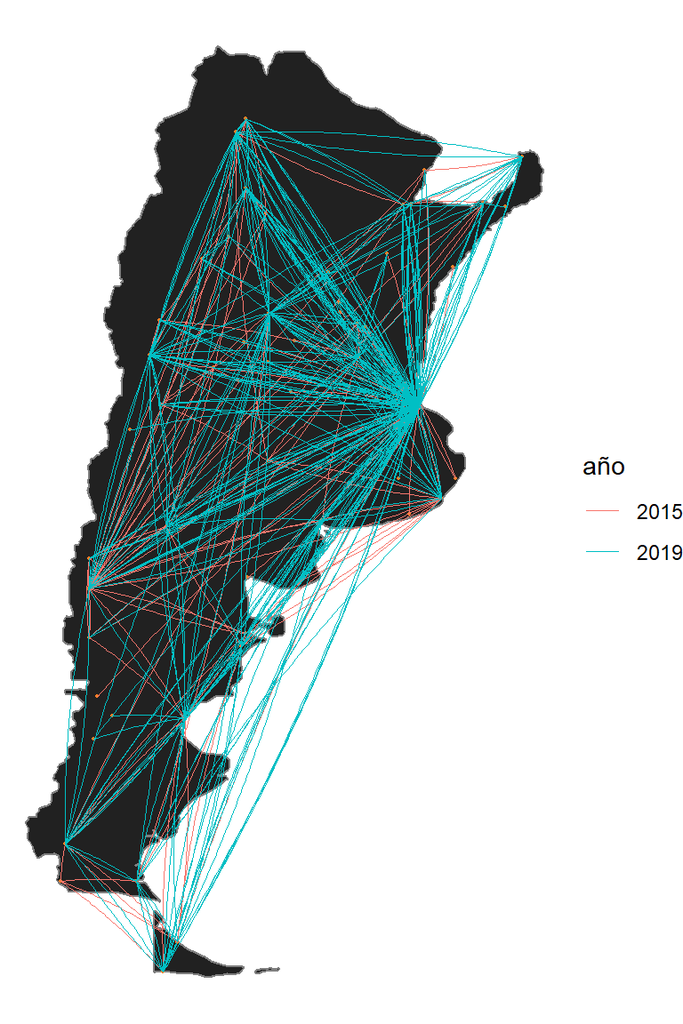

```r
v_2015 <- datos_2015 %>%
  filter(!is.na(Origen.OACI), !is.na(Destino.OACI),
         Origen.OACI != Destino.OACI) %>%
  select(Origen.OACI, Destino.OACI, Ciudad.Origen, Ciudad.Destino,
         lat_origen, lon_origen, lat_destino, lon_destino) %>%
  distinct() %>%
  drop_na(lat_origen, lon_origen, lat_destino, lon_destino) %>%
  filter(lat_origen != lat_destino | lon_origen != lon_destino) %>%
  mutate(anio="2015") %>%
  as_tibble()

v_2019 <- datos_2019 %>%
  filter(!is.na(Origen.OACI), !is.na(Destino.OACI),
         Origen.OACI != Destino.OACI) %>%
  select(Origen.OACI, Destino.OACI, Ciudad.Origen, Ciudad.Destino,
         lat_origen, lon_origen, lat_destino, lon_destino) %>%
  distinct() %>%
  drop_na(lat_origen, lon_origen, lat_destino, lon_destino) %>%
  filter(lat_origen != lat_destino | lon_origen != lon_destino) %>%
  mutate(anio="2019") %>%
  as_tibble()

v_tot <- rbind(v_2015, v_2019)

mapa_arg <- ggplot() +
  borders(database = "world", regions = c("argentina"), fill = 'grey13')

mapa_arg +
  geom_point(data=v_tot,
             aes(x=lon_origen, y=lat_origen),
             size=.3,
             col="chocolate1") +
  geom_point(data=v_tot,
             aes(x=lon_destino, y=lat_destino),
             size=.3,
             col="chocolate1") +
  geom_curve(data = v_tot,
             aes(x= lon_origen, y=lat_origen, xend=lon_destino, yend=lat_destino, col=anio),
             size=.1,
             curvature=.06) +
  labs(col="año") +
  theme_void()
```

El mapa muestra las rutas registradas en cada año. Permite reconocer conexiones compartidas y rutas que aparecen en uno de los dos períodos. Cada curva representa una ruta, no su frecuencia de vuelos.

Ahora, surge naturalmente la duda de saber cuántos vuelos hubo en cada año:

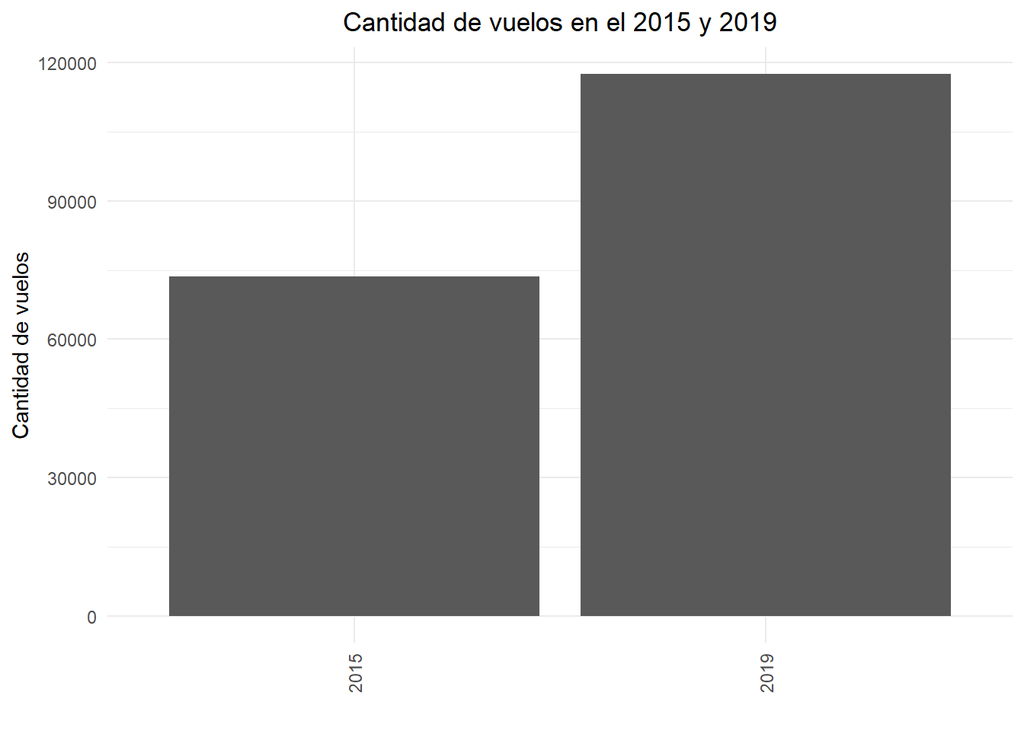

Cantidad de vuelos en el 2015 y 2019

```r
cant_vuelos_2015 <-  datos_2015 %>%
  count(sort=T) %>%
  mutate(anio = "2015" )

cant_vuelos_2019 <-  datos_2019 %>%
  count(sort=T) %>%
  mutate(anio = "2019" )

cant_vuelos_totales <- rbind(cant_vuelos_2015, cant_vuelos_2019)

ggplot(cant_vuelos_totales, aes(x= anio, y=n)) +
  geom_bar(stat='identity', position='dodge') +
  theme_minimal() +
  ylab("Cantidad de vuelos") +
  xlab("") +
  ggtitle("Cantidad de vuelos en el 2015 y 2019") +
   theme(axis.text.x = element_text(angle = 90, vjust = 0.5, hjust=1), plot.title = element_text(hjust = 0.5))
```

En 2015 se retuvieron 73.688 despegues y en 2019, 117.497. La variación fue del 59,5%. A continuación analizamos cómo se distribuyó ese cambio entre regiones.

## Vuelos a nivel regional

Consideramos útil, a los efectos de nuestro trabajo, la división del territorio nacional en cinco regiones principales: Cuyo, Buenos Aires, Patagonia, Norte y Centro, según el siguiente mapa. Para ello, agregamos una columna con la información a la región.

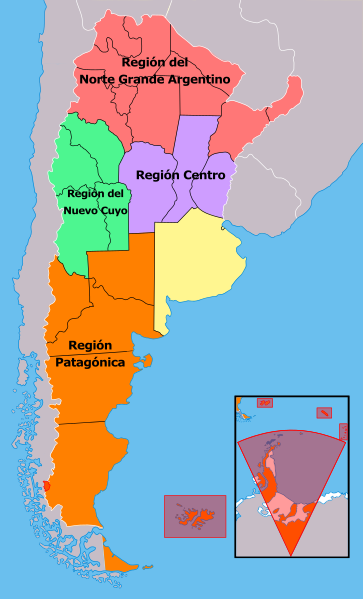

Mapa de regiones

```r
vec_norte <- c("Salta", "Formosa", "Tucumán", "Chaco", "Jujuy", "Misiones",
               "Catamarca", "Corrientes", "Santiago del Estero")
asignar_region <- function(provincia) {
  case_when(
    provincia %in% c("San Juan", "Mendoza", "La Rioja", "San Luis") ~ "Cuyo",
    provincia %in% c("Buenos Aires", "Buenos Aires City", "Autonomous City of Buenos Aires",
                     "Ciudad Autónoma de Buenos Aires", "CABA") ~ "Buenos Aires",
    provincia %in% c("Chubut", "Río Negro", "Santa Cruz", "Tierra del Fuego",
                     "Neuquén", "La Pampa") ~ "Patagonia",
    provincia %in% vec_norte ~ "Norte",
    provincia %in% c("Córdoba", "Santa Fe", "Entre Ríos") ~ "Centro",
    TRUE ~ NA_character_
  )
}
datos_2015 <- datos_2015 %>% mutate(
  Region.Origen = asignar_region(Provincia.Origen),
  Region.Destino = asignar_region(Provincia.Destino)
)
datos_2019 <- datos_2019 %>% mutate(
  Region.Origen = asignar_region(Provincia.Origen),
  Region.Destino = asignar_region(Provincia.Destino)
)
control_regiones <- bind_rows(
  datos_2015 %>% summarise(anio = 2015,
    sin_region_origen = sum(is.na(Region.Origen)),
    sin_region_destino = sum(is.na(Region.Destino))),
  datos_2019 %>% summarise(anio = 2019,
    sin_region_origen = sum(is.na(Region.Origen)),
    sin_region_destino = sum(is.na(Region.Destino)))
)
control_regiones
```

| anio | sin_region_origen | sin_region_destino |
| --- | --- | --- |
| 2015 | 8 | 92 |
| 2019 | 40 | 122 |

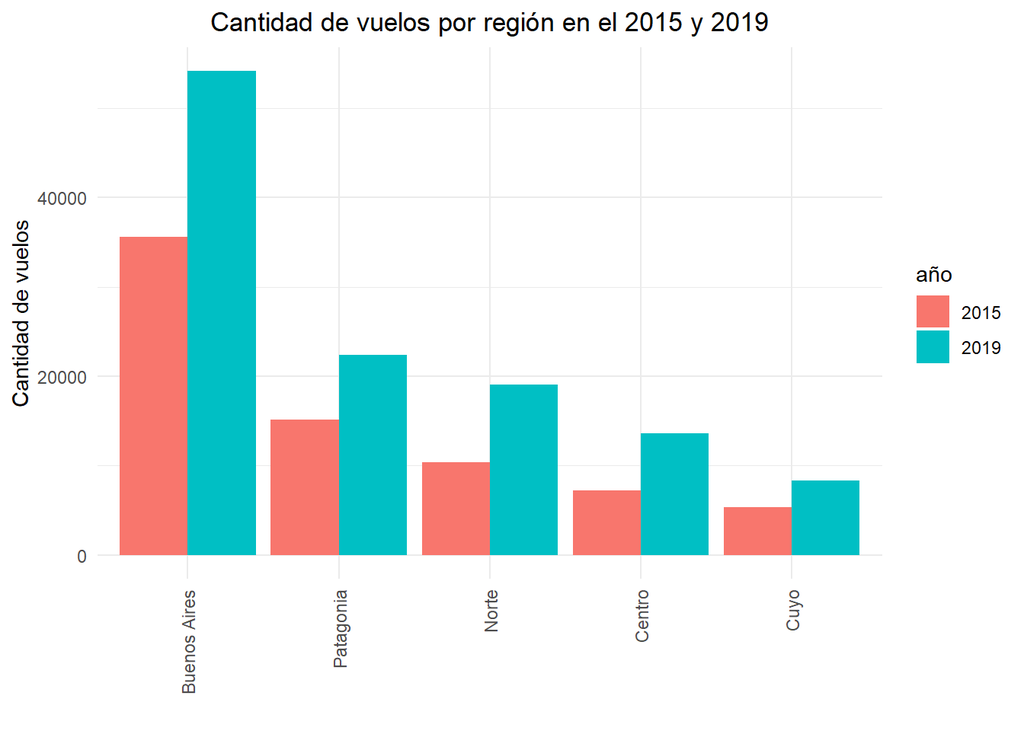

Cantidad de vuelos por región en el 2015 y 2019

```r
cant_vxRegion_2015 <-  datos_2015 %>%
  filter(!is.na(Region.Origen)) %>%
  group_by(Region.Origen) %>%
  count(sort=T) %>%
  mutate(anio = "2015" )

cant_vxRegion_2019 <-  datos_2019 %>%
  filter(!is.na(Region.Origen)) %>%
  group_by(Region.Origen) %>%
  count(sort=T) %>%
  mutate(anio = "2019" )

cant_vxRegion <- rbind(cant_vxRegion_2015, cant_vxRegion_2019)

ggplot(cant_vxRegion, aes(x=reorder(Region.Origen,-n), y=n, fill=anio)) +
  geom_bar(stat='identity', position='dodge') +
  theme_minimal() +
  ylab("Cantidad de vuelos") +
  xlab("") +
  labs(fill = "año") +
  ggtitle("Cantidad de vuelos por región en el 2015 y 2019") +
   theme(axis.text.x = element_text(angle = 90, vjust = 0.5, hjust=1), plot.title = element_text(hjust = 0.5))
```

El gráfico por región compara los despegues por región de origen. La siguiente tabla cuantifica su variación. Los vuelos sin región de origen identificada quedan fuera de esta comparación, pero se conservan en el total nacional.

```r
t_2015 <- cant_vxRegion_2015 %>%
  select(-c(anio)) %>%
  rename(vuelos_2015 = n)

t_2019 <- cant_vxRegion_2019 %>%
  select(-c(anio)) %>%
  rename(vuelos_2019 =n)

t_dif_regiones <- full_join(t_2015, t_2019, by="Region.Origen") %>%
  mutate(vuelos_2015 = replace_na(vuelos_2015, 0L),
         vuelos_2019 = replace_na(vuelos_2019, 0L),
         dif_porcentual = ifelse(vuelos_2015 > 0,
           100 * (vuelos_2019 - vuelos_2015) / vuelos_2015, NA_real_)) %>%
  arrange(desc(dif_porcentual))
t_dif_regiones
```

| Region.Origen | vuelos_2015 | vuelos_2019 | dif_porcentual |
| --- | --- | --- | --- |
| Centro | 7226 | 13592 | 88.09853 |
| Norte | 10373 | 19056 | 83.70770 |
| Cuyo | 5372 | 8288 | 54.28146 |
| Buenos Aires | 35575 | 54116 | 52.11806 |
| Patagonia | 15134 | 22405 | 48.04414 |

La región con mayor variación porcentual calculable fue Centro, con un 88,1%. La tabla permite comparar ese cambio relativo con la cantidad de vuelos de cada región. Si una región no tiene vuelos registrados en 2015, su variación porcentual se deja como faltante porque no hay una base positiva para calcularla.

A partir de estos datos, nos preguntamos cómo fue ese cambio en la región Norte, si fue uniforme en todas las provincias o si hubo algunas que se destacaron por sobre las otras.

## Vuelos a nivel provincial y local

```r
# Contamos despegues por provincia de origen del Norte.
# Cada fila retenida representa un despegue y se cuenta una sola vez.
datos_norte_2015 <- datos_2015 %>%
  filter(Region.Origen == "Norte")
datos_norte_2019 <- datos_2019 %>%
  filter(Region.Origen=="Norte")
```

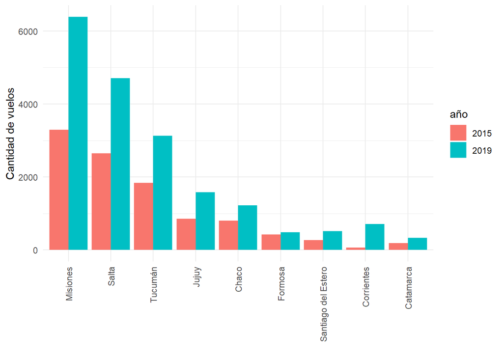

Cantidad de vuelos por provincias (región Norte)

```r
cant_vxProv_2015 <-  datos_norte_2015 %>%
  group_by(Provincia.Origen) %>%
  count(sort=T) %>%
  mutate(anio = "2015" )

cant_vxProv_2019 <-  datos_norte_2019 %>%
  group_by(Provincia.Origen) %>%
  count(sort=T) %>%
  mutate(anio = "2019" )

cant_vxProv <- rbind(cant_vxProv_2015, cant_vxProv_2019)

ggplot(cant_vxProv, aes(x=reorder(Provincia.Origen,-n), y=n, fill=anio)) +
  geom_bar(stat='identity', position='dodge') +
  theme_minimal() +
  ylab("Cantidad de vuelos") +
  xlab("") +
  labs(fill = "año") +
  theme(axis.text.x = element_text(angle = 90, vjust = 0.5, hjust=1))
```

El gráfico por provincia muestra la cantidad de despegues por provincia. Calculamos también la variación porcentual para distinguir el tamaño de cada operación de su cambio relativo.

```r
t_2015 <- cant_vxProv_2015 %>%
  select(-c(anio)) %>%
  rename(vuelos_2015 = n)

t_2019 <- cant_vxProv_2019 %>%
  select(-c(anio)) %>%
  rename(vuelos_2019 =n)

t_dif_prov <- full_join(t_2015, t_2019, by="Provincia.Origen") %>%
  mutate(vuelos_2015 = replace_na(vuelos_2015, 0L),
         vuelos_2019 = replace_na(vuelos_2019, 0L),
         dif_porcentual = ifelse(vuelos_2015 > 0,
           100 * (vuelos_2019 - vuelos_2015) / vuelos_2015, NA_real_)) %>%
  arrange(desc(dif_porcentual))
t_dif_prov
```

| Provincia.Origen | vuelos_2015 | vuelos_2019 | dif_porcentual |
| --- | --- | --- | --- |
| Corrientes | 65 | 706 | 986.15385 |
| Misiones | 3297 | 6385 | 93.66090 |
| Santiago del Estero | 266 | 514 | 93.23308 |
| Jujuy | 850 | 1584 | 86.35294 |
| Salta | 2651 | 4702 | 77.36703 |
| Catamarca | 191 | 326 | 70.68063 |
| Tucumán | 1835 | 3129 | 70.51771 |
| Chaco | 800 | 1227 | 53.37500 |
| Formosa | 418 | 483 | 15.55024 |

En Corrientes se registraron 65 despegues en 2015 y 706 en 2019, una variación del 986,2%. Un cambio porcentual grande debe leerse junto con la cantidad inicial de vuelos. La cercanía entre Corrientes y Resistencia puede ser relevante para interpretar su actividad, aunque estos datos no permiten afirmar que una haya sustituido a la otra.

En Formosa, la variación fue del 15,6%, frente a una mediana provincial del 77,4%. La diferencia respecto de esa mediana fue de -61,8 puntos porcentuales (Formosa menos la mediana).

```
##    Min. 1st Qu.  Median    Mean 3rd Qu.    Max.
##   15.55   70.52   77.37  171.88   93.23  986.15
```

### Conectividad de las ciudades de la región Norte

Luego de comparar la cantidad de vuelos, cabe preguntarse si cambió la conectividad de las ciudades de la región Norte. Para estudiar esto, armamos grafos con las rutas que tienen al menos un extremo en esta región. Cada nodo representa una ciudad y cada arista indica que existió al menos un vuelo entre dos ciudades durante el año analizado. Usamos un grafo simple no dirigido: contamos una sola conexión por par de ciudades, aunque haya vuelos en ambos sentidos. Así, el grado de cada nodo es la cantidad de ciudades distintas con las que se conecta dentro de este conjunto de rutas.

```r
# Para estudiar conexiones necesitamos conocer ambas ciudades y poder
# identificar al menos uno de los extremos como perteneciente al Norte.
datos_rutas_norte_2015 <- datos_2015 %>%
  filter(Region.Origen %in% "Norte" | Region.Destino %in% "Norte") %>%
  drop_na(Ciudad.Origen, Ciudad.Destino)

edges_2015_norte <- datos_rutas_norte_2015 %>%
  select(Ciudad.Origen, Ciudad.Destino) %>%
  filter(Ciudad.Origen != Ciudad.Destino) %>%
  distinct()

datos_rutas_norte_2019 <- datos_2019 %>%
  filter(Region.Origen %in% "Norte" | Region.Destino %in% "Norte") %>%
  drop_na(Ciudad.Origen, Ciudad.Destino)

edges_2019_norte <- datos_rutas_norte_2019 %>%
  select(Ciudad.Origen, Ciudad.Destino) %>%
  filter(Ciudad.Origen != Ciudad.Destino) %>%
  distinct()
```

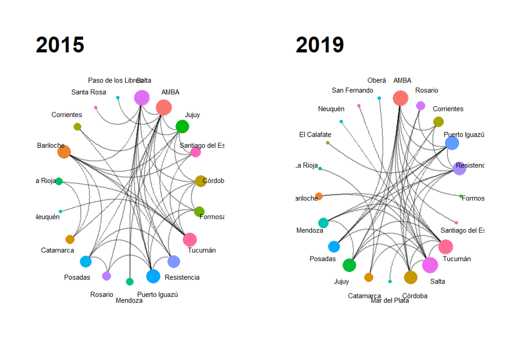

```r
# Al hacer el grafo no dirigido, A-B y B-A pueden quedar como aristas
# paralelas. simplify elimina esa duplicación antes de calcular el grado.
g_2015 <- igraph::graph_from_data_frame(edges_2015_norte, directed=FALSE) %>%
  igraph::simplify(remove.multiple=TRUE, remove.loops=TRUE)
g_2015 <- igraph::set_vertex_attr(
  g_2015, "grado", value=igraph::degree(g_2015, loops=FALSE)
) %>%
  as_tbl_graph()

g_2019 <- igraph::graph_from_data_frame(edges_2019_norte, directed=FALSE) %>%
  igraph::simplify(remove.multiple=TRUE, remove.loops=TRUE)
g_2019 <- igraph::set_vertex_attr(
  g_2019, "grado", value=igraph::degree(g_2019, loops=FALSE)
) %>%
  as_tbl_graph()

# Los gráficos interactivos usarán las mismas aristas que estos grafos.
# Los nombres Origen/Destino aquí identifican los extremos de cada arista;
# no indican una dirección del vuelo en este grafo no dirigido.
edges_2015_norte <- igraph::as_data_frame(g_2015, what="edges") %>%
  rename(Ciudad.Origen=from, Ciudad.Destino=to)
edges_2019_norte <- igraph::as_data_frame(g_2019, what="edges") %>%
  rename(Ciudad.Origen=from, Ciudad.Destino=to)

p_2015 <- g_2015 %>%
  ggraph(layout='linear', circular=TRUE) +
  geom_edge_arc(edge_width=.5, alpha=.4) +
  geom_node_point(aes(color=name, size=grado), show.legend=FALSE) +
  ggtitle("2015") +
  theme_graph(base_family="sans")

p_2015 <- p_2015 +
  geom_node_text(aes(label=name),
                 nudge_x=p_2015$data$x * .2,
                 nudge_y=p_2015$data$y * .2,
                 size=2)

p_2019 <- g_2019 %>%
  ggraph(layout='linear', circular=TRUE) +
  geom_edge_arc(edge_width=.5, alpha=.4) +
  geom_node_point(aes(color=name, size=grado), show.legend=FALSE) +
  ggtitle("2019") +
  theme_graph(base_family="sans")

p_2019 <- p_2019 +
  geom_node_text(aes(label=name),
                 nudge_x=p_2019$data$x * .2,
                 nudge_y=p_2019$data$y * .2,
                 size=2)

grid.arrange(p_2015, p_2019, ncol=2)
```

Para explorar las conexiones de cada ciudad, dejamos el siguiente grafo interactivo correspondiente al año 2015:

```r
simpleNetwork(edges_2015_norte,
              Source="Ciudad.Origen",
              Target="Ciudad.Destino",
              linkDistance=90,
              fontSize=10,
              charge=-80,
              nodeColour="#F8766D",
              zoom=FALSE)
```

[interactive chart not shown]

Y el siguiente, correspondiente a 2019:

```r
simpleNetwork(edges_2019_norte,
              Source="Ciudad.Origen",
              Target="Ciudad.Destino",
              linkDistance=90,
              fontSize=10,
              nodeColour="#619CFF",
              charge=-70,
              zoom=FALSE)
```

[interactive chart not shown]

Las siguientes tablas muestran las diez ciudades con más conexiones dentro de este subgrafo. Incluyen tanto ciudades del Norte como ciudades de otras regiones conectadas con él; por eso, no representan un ranking exclusivo de ciudades norteñas. Ante un empate en el grado, ordenamos por nombre.

```r
conectividad_2015 <- g_2015 %>%
  activate(nodes) %>%
  as.data.frame() %>%
  select(name, grado) %>%
  arrange(desc(grado), name)

tConectividad_2015 <- conectividad_2015 %>%
  head(10) %>%
  rename("Ciudades 2015"=name)
tConectividad_2015
```

|  | Ciudades 2015 | grado |
| --- | --- | --- |
| 1 | AMBA | 11 |
| 2 | Salta | 10 |
| 3 | Puerto Iguazú | 8 |
| 4 | Tucumán | 8 |
| 5 | Bariloche | 7 |
| 6 | Jujuy | 7 |
| 7 | Resistencia | 6 |
| 8 | Córdoba | 5 |
| 9 | Posadas | 5 |
| 10 | Formosa | 4 |

```r
conectividad_2019 <- g_2019 %>%
  activate(nodes) %>%
  as.data.frame() %>%
  select(name, grado) %>%
  arrange(desc(grado), name)

tConectividad_2019 <- conectividad_2019 %>%
  head(10) %>%
  rename("Ciudades 2019"=name)
tConectividad_2019
```

|  | Ciudades 2019 | grado |
| --- | --- | --- |
| 1 | Salta | 11 |
| 2 | AMBA | 10 |
| 3 | Tucumán | 9 |
| 4 | Puerto Iguazú | 8 |
| 5 | Córdoba | 7 |
| 6 | Jujuy | 7 |
| 7 | Resistencia | 7 |
| 8 | Posadas | 5 |
| 9 | Corrientes | 4 |
| 10 | Mendoza | 4 |

### Flujo de vuelos desde ciudades de la región Norte

Además de contar conexiones, nos interesa conocer cuántos vuelos recorren cada ruta. Para esto, seleccionamos hasta diez ciudades del Norte según su cantidad de conexiones. Primero restringimos el ranking a las ciudades de esta región y luego elegimos las de mayor grado, con desempate por nombre. La selección se realiza por separado para cada año, por lo que las ciudades representadas pueden cambiar.

```r
# Identificamos las ciudades del Norte usando ambos extremos de los vuelos.
ciudades_norte_2015 <- bind_rows(
  datos_rutas_norte_2015 %>%
    filter(Region.Origen %in% "Norte") %>%
    transmute(name=Ciudad.Origen),
  datos_rutas_norte_2015 %>%
    filter(Region.Destino %in% "Norte") %>%
    transmute(name=Ciudad.Destino)
) %>%
  distinct(name)

ciudades_norte_2019 <- bind_rows(
  datos_rutas_norte_2019 %>%
    filter(Region.Origen %in% "Norte") %>%
    transmute(name=Ciudad.Origen),
  datos_rutas_norte_2019 %>%
    filter(Region.Destino %in% "Norte") %>%
    transmute(name=Ciudad.Destino)
) %>%
  distinct(name)

tConectividadNorte_2015 <- conectividad_2015 %>%
  semi_join(ciudades_norte_2015, by="name") %>%
  arrange(desc(grado), name) %>%
  head(10)

tConectividadNorte_2019 <- conectividad_2019 %>%
  semi_join(ciudades_norte_2019, by="name") %>%
  arrange(desc(grado), name) %>%
  head(10)

# Para los flujos volvemos a los registros de vuelos: conservamos su
# dirección y contamos todos los despegues, no las aristas del grafo simple.
v_salida_norte_2015 <- datos_rutas_norte_2015 %>%
  filter(Region.Origen %in% "Norte",
         Ciudad.Origen %in% tConectividadNorte_2015$name,
         Ciudad.Origen != Ciudad.Destino)

v_salida_norte_2019 <- datos_rutas_norte_2019 %>%
  filter(Region.Origen %in% "Norte",
         Ciudad.Origen %in% tConectividadNorte_2019$name,
         Ciudad.Origen != Ciudad.Destino)
```

En los diagramas Sankey, las ciudades de origen están a la izquierda y sus destinos a la derecha. El ancho de cada banda representa la cantidad de vuelos en esa dirección.

```r
# Las filas son ciudades de origen y las columnas, ciudades de destino.
data <- table(v_salida_norte_2015$Ciudad.Origen,
              v_salida_norte_2015$Ciudad.Destino) %>%
  as.data.frame.matrix()

links <- data %>%
  tibble::rownames_to_column(var="source") %>%
  gather(key="target", value="value", -1) %>%
  mutate(target=tolower(target)) %>%
  filter(value != 0)

# Los destinos se escriben en minúscula para mantener separados los nodos
# de origen y destino cuando una ciudad aparece a ambos lados del diagrama.
nodes <- data.frame(
  name=unique(c(as.character(links$source), as.character(links$target)))
)
links$IDsource <- match(links$source, nodes$name) - 1
links$IDtarget <- match(links$target, nodes$name) - 1

sankeyNetwork(Links=links, Nodes=nodes,
              Source="IDsource",
              Target="IDtarget",
              Value="value",
              NodeID="name",
              fontSize=12,
              nodeWidth=40)
```

[interactive chart not shown]

Vuelos desde las ciudades seleccionadas del Norte en 2015

*Nota:* Para ver el número de vuelos de una ciudad a otra, sugerimos mantener el cursor durante unos segundos sobre la banda deseada.

```r
data <- table(v_salida_norte_2019$Ciudad.Origen,
              v_salida_norte_2019$Ciudad.Destino) %>%
  as.data.frame.matrix()

links <- data %>%
  tibble::rownames_to_column(var="source") %>%
  gather(key="target", value="value", -1) %>%
  mutate(target=tolower(target)) %>%
  filter(value != 0)

nodes <- data.frame(
  name=unique(c(as.character(links$source), as.character(links$target)))
)
links$IDsource <- match(links$source, nodes$name) - 1
links$IDtarget <- match(links$target, nodes$name) - 1

sankeyNetwork(Links=links, Nodes=nodes,
              Source="IDsource",
              Target="IDtarget",
              Value="value",
              NodeID="name",
              fontSize=12,
              nodeWidth=40)
```

[interactive chart not shown]

Vuelos desde las ciudades seleccionadas del Norte en 2019

## Aerolíneas más voladas a nivel nacional en 2015 y 2019

Pasemos a continuación a un análisis de las empresas. Nos centraremos en las cinco aerolíneas con más despegues regulares no internacionales en cada año y compararemos su composición. Para este conteo nacional no necesitamos conocer la ciudad ni las coordenadas de los aeropuertos, por lo que conservamos los vuelos aunque falte esa información.

```r
cant_vxAerolineas_2015 <- datos_2015 %>%
  count(Aerolinea.Nombre, name="n") %>%
  arrange(desc(n), Aerolinea.Nombre)

filtro_top_5_2015 <- cant_vxAerolineas_2015 %>%
  head(5) %>%
  pull(Aerolinea.Nombre)

datos_top5_2015 <- datos_2015 %>%
  filter(Aerolinea.Nombre %in% filtro_top_5_2015)

cant_vxAerolineas_2019 <- datos_2019 %>%
  count(Aerolinea.Nombre, name="n") %>%
  arrange(desc(n), Aerolinea.Nombre)

filtro_top_5_2019 <- cant_vxAerolineas_2019 %>%
  head(5) %>%
  pull(Aerolinea.Nombre)

datos_top5_2019 <- datos_2019 %>%
  filter(Aerolinea.Nombre %in% filtro_top_5_2019)
```

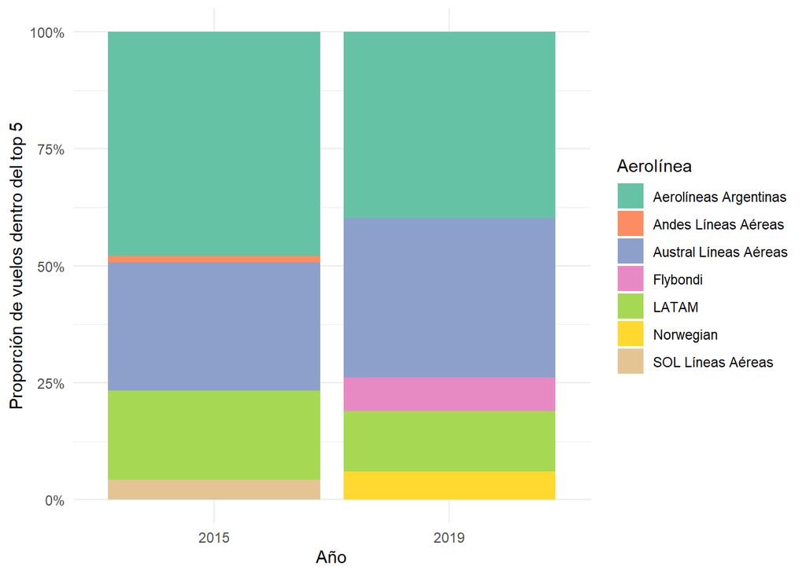

Composición de los vuelos entre las cinco principales aerolíneas nacionales de cada año

```r
rbind(datos_top5_2015 %>% mutate(anio=2015),
      datos_top5_2019 %>% mutate(anio=2019)) %>%
  count(anio, Aerolinea.Nombre, name="n") %>%
  ggplot(aes(x=factor(anio), y=n, fill=Aerolinea.Nombre)) +
  geom_col(position="fill") +
  scale_y_continuous(labels=function(x) paste0(round(100*x), "%")) +
  scale_fill_brewer(palette="Set2") +
  labs(x="Año", y="Proporción de vuelos dentro del top 5", fill="Aerolínea") +
  theme_minimal()
```

**Análisis cuantitativo**

En las tablas, `n` es la cantidad de vuelos de cada aerolínea y `pct_vuelos_top5` es su porcentaje sobre el total de vuelos de las cinco empresas seleccionadas en ese año. Este denominador no incluye al resto de las aerolíneas, por lo que los porcentajes no representan participaciones en el mercado total.

**2015**

```r
tParticipacion_top5_2015 <- datos_top5_2015 %>%
  count(Aerolinea.Nombre, name="n") %>%
  mutate(pct_vuelos_top5=round(100 * n / sum(n), 2)) %>%
  arrange(desc(n), Aerolinea.Nombre)

tParticipacion_top5_2015
```

| Aerolinea.Nombre | n | pct_vuelos_top5 |
| --- | --- | --- |
| Aerolíneas Argentinas | 34960 | 47.88 |
| Austral Líneas Aéreas | 20043 | 27.45 |
| LATAM | 13844 | 18.96 |
| SOL Líneas Aéreas | 3157 | 4.32 |
| Andes Líneas Aéreas | 1013 | 1.39 |

**2019**

```r
tParticipacion_top5_2019 <- datos_top5_2019 %>%
  count(Aerolinea.Nombre, name="n") %>%
  mutate(pct_vuelos_top5=round(100 * n / sum(n), 2)) %>%
  arrange(desc(n), Aerolinea.Nombre)

tParticipacion_top5_2019
```

| Aerolinea.Nombre | n | pct_vuelos_top5 |
| --- | --- | --- |
| Aerolíneas Argentinas | 43711 | 39.81 |
| Austral Líneas Aéreas | 37393 | 34.06 |
| LATAM | 14310 | 13.03 |
| Flybondi | 7780 | 7.09 |
| Norwegian | 6601 | 6.01 |

Las aerolíneas seleccionadas reúnen 73017 vuelos en 2015 y 109795 en 2019. Comparar los nombres, los conteos y los porcentajes permite distinguir cambios en la composición del grupo de cambios en el volumen de vuelos. Una variación en la participación relativa no implica por sí sola que una empresa haya aumentado o reducido su cantidad de vuelos.

### Aerolíneas del top 5 nacional con vuelos vinculados al Norte

Retomando nuestra inquietud sobre la región Norte, analizamos los vuelos que tienen origen o destino en ella, manteniendo las cinco aerolíneas seleccionadas a nivel nacional en cada año. Por lo tanto, esta selección no constituye un nuevo ranking de las cinco principales empresas del Norte. Incluimos los registros en los que al menos uno de los extremos puede identificarse como perteneciente a esta región.

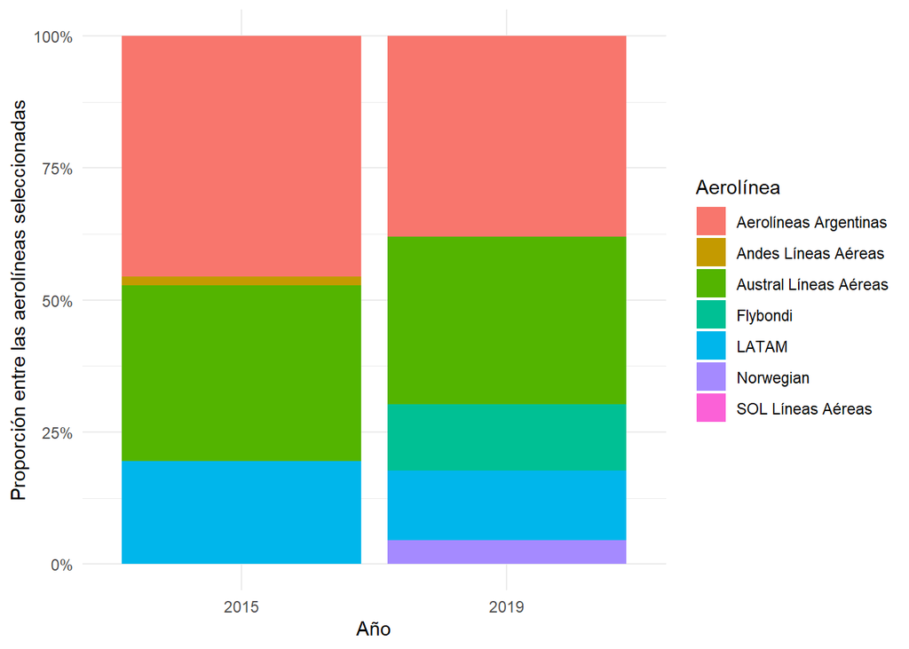

Aerolíneas del top 5 nacional: composición de sus vuelos vinculados al Norte en cada año

```r
datos_top5Norte_2015 <- datos_top5_2015 %>%
  filter(Region.Origen %in% "Norte" | Region.Destino %in% "Norte") %>%
  select(Aerolinea.Nombre) %>%
  mutate(anio=2015)

datos_top5Norte_2019 <- datos_top5_2019 %>%
  filter(Region.Origen %in% "Norte" | Region.Destino %in% "Norte") %>%
  select(Aerolinea.Nombre) %>%
  mutate(anio=2019)

df_vuelosAerolineas <- rbind(datos_top5Norte_2015, datos_top5Norte_2019)

df_vuelosAerolineas %>%
  count(anio, Aerolinea.Nombre, name="n") %>%
  ggplot(aes(x=factor(anio), y=n, fill=Aerolinea.Nombre)) +
  geom_col(position="fill") +
  scale_y_continuous(labels=function(x) paste0(round(100*x), "%")) +
  labs(x="Año", y="Proporción entre las aerolíneas seleccionadas", fill="Aerolínea") +
  theme_minimal()
```

En estas tablas, `pct_vuelos_top5_nacional_en_norte` usa como denominador únicamente los vuelos vinculados al Norte de las aerolíneas del top 5 nacional de cada año. Conservamos también `n` para comparar cantidades.

**2015**

```r
tParticipacion_Norte_2015 <- datos_top5Norte_2015 %>%
  count(Aerolinea.Nombre, name="n") %>%
  mutate(pct_vuelos_top5_nacional_en_norte=round(100 * n / sum(n), 2)) %>%
  arrange(desc(n), Aerolinea.Nombre)

tParticipacion_Norte_2015
```

| Aerolinea.Nombre | n | pct_vuelos_top5_nacional_en_norte |
| --- | --- | --- |
| Aerolíneas Argentinas | 9352 | 45.50 |
| Austral Líneas Aéreas | 6852 | 33.34 |
| LATAM | 3996 | 19.44 |
| Andes Líneas Aéreas | 351 | 1.71 |
| SOL Líneas Aéreas | 2 | 0.01 |

**2019**

```r
tParticipacion_Norte_2019 <- datos_top5Norte_2019 %>%
  count(Aerolinea.Nombre, name="n") %>%
  mutate(pct_vuelos_top5_nacional_en_norte=round(100 * n / sum(n), 2)) %>%
  arrange(desc(n), Aerolinea.Nombre)

tParticipacion_Norte_2019
```

| Aerolinea.Nombre | n | pct_vuelos_top5_nacional_en_norte |
| --- | --- | --- |
| Aerolíneas Argentinas | 13302 | 38.02 |
| Austral Líneas Aéreas | 11106 | 31.75 |
| LATAM | 4612 | 13.18 |
| Flybondi | 4395 | 12.56 |
| Norwegian | 1570 | 4.49 |

Dentro de esta selección, se registran 20553 vuelos vinculados al Norte en 2015 y 34985 en 2019. Las tablas permiten comparar la composición y los volúmenes observados, pero no atribuir sus cambios a la entrada de una empresa ni a otras causas.

## Reflexiones finales

Analizamos los despegues regulares no internacionales de 2015 y 2019 desde distintas escalas: nacional, regional, provincial y entre ciudades. También comparamos la cantidad de conexiones con el volumen de vuelos y la composición de las aerolíneas seleccionadas. Estas medidas responden preguntas distintas: una ciudad puede tener más conexiones sin que cada ruta tenga una mayor frecuencia.

Los resultados describen los registros disponibles. Las comparaciones geográficas dependen de la información que pudo asociarse a cada aeropuerto, mientras que los porcentajes de aerolíneas se refieren a los grupos seleccionados. Este análisis exploratorio permite formular nuevas preguntas sobre los cambios observados, pero no establece sus causas.